# Analiza zachowania VTI i Brent OIL wokół inwazji na Ukrainę

Wszystkie wykresy jako kolor zielony przyjmują dane sprzed kryzysu, a czerwony w czasie kryzysu

## Olej przed i po

Olej brent: https://finance.yahoo.com/quote/BZ=F/

Jako, że Rosja jest dużym eksporterem energii, w tym także ropy, a konflikt z krajem buforowym do NATO powinien spowodować ograniczoną podaż (spowodowaną sankcjami UE), co powinno podnieść ceny ropy. Wolumen także powinien wzrosnąć.

# Wolumen

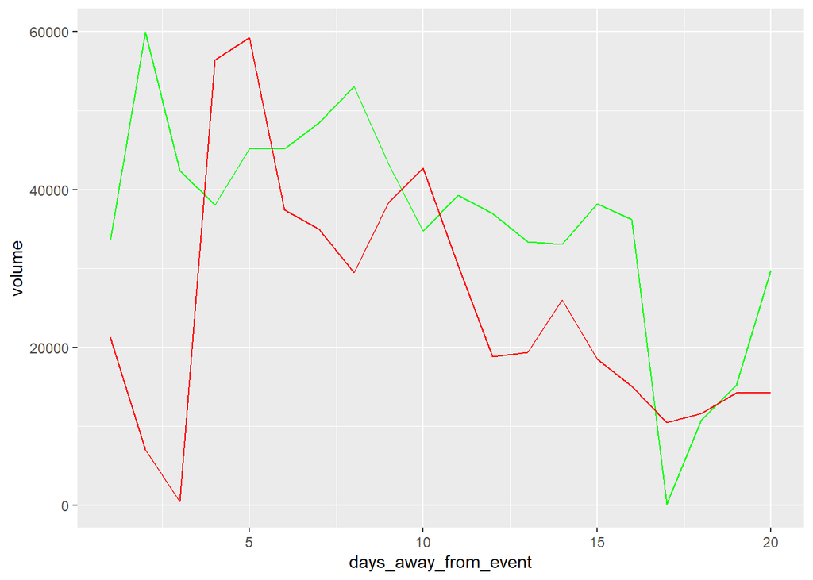

```r
ggplot() +
geom_line(data=oil_pre.out$df.tickers, aes(x=days_away_from_event, y=volume), color='green') +
geom_line(data=oil_post.out$df.tickers, aes(x=days_away_from_event, y=volume), color='red')
```

Jak widać - wolumen w dużej mierze spadł, szczególnie w pierwszych dniach, odbijając się około 5 dnia.

Może to być spowodowane wzrostem ceny i niepewnością jaki będzie wynik wojny

# Stopy zwrotu

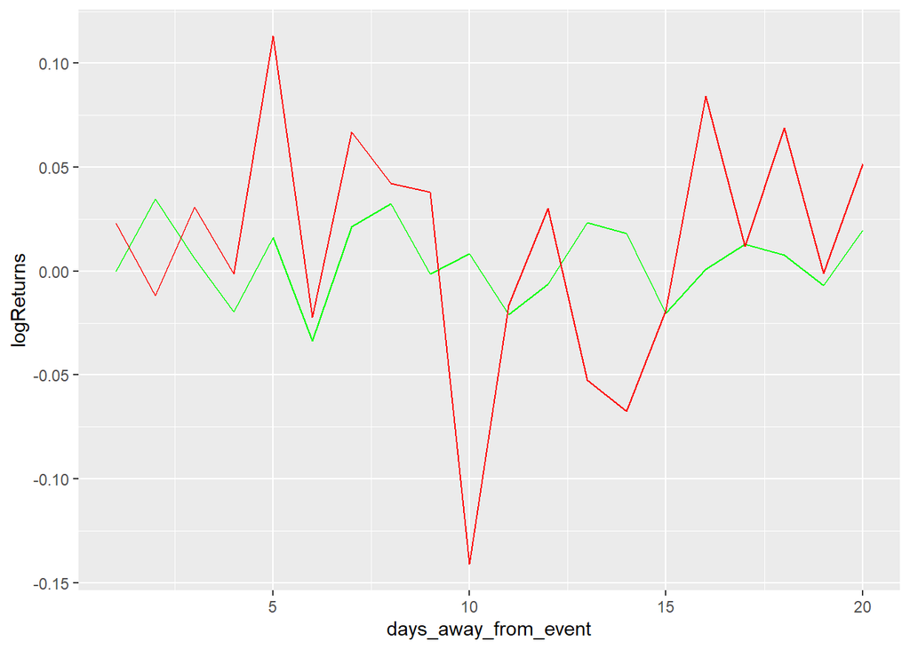

```r
ggplot() +
geom_line(data=oil_pre.out$df.tickers, aes(x=days_away_from_event, y=logReturns), color='green') +
geom_line(data=oil_post.out$df.tickers, aes(x=days_away_from_event, y=logReturns), color='red')
```

Stopy zwrotu po kryzysie są widocznie wyższe od zwrotów przed kryzysem, inaczej mówiąc wyższe ceny ropy.

Najprostszym tego wytłumaczeniem jest niepewność na rynku, co do wyniku wojny a także co do sankcji nałożonych na Rosję.

# Srednie

```r
summary(oil_pre.out$df.tickers[c("volume", "logReturns")])
```

```
##      volume        logReturns
##  Min.   :  118   Min.   :-0.033700
##  1st Qu.:33283   1st Qu.:-0.006375
##  Median :37531   Median : 0.006900
##  Mean   :35844   Mean   : 0.004685
##  3rd Qu.:43713   3rd Qu.: 0.018600
##  Max.   :59945   Max.   : 0.034700
```

```r
summary(oil_post.out$df.tickers[c("volume", "logReturns")])
```

```
##      volume        logReturns
##  Min.   :  448   Min.   :-0.14110
##  1st Qu.:14270   1st Qu.:-0.01707
##  Median :20323   Median : 0.01745
##  Mean   :25317   Mean   : 0.01138
##  3rd Qu.:35593   3rd Qu.: 0.04462
##  Max.   :59273   Max.   : 0.11310
```

Liczby potwierdzają obserwacje “na oko” co do zwrotów i woluminów. Woluminy przed były większe, ale stopy zwrotu mniejsze.

## VTI przed i po

ETF Vanguarda Total Stock Market Infex Fund: https://finance.yahoo.com/quote/VTI/ Kupowany częściej przez tzw. Bogleheads, ludzi inwestujących zasadami Johna Bogle’a

- dywersyfikacja, którą VTI oferuje
- niskie koszty operacyjne (raz kupujesz ETF i płacisz niskie expense ratio)
- time in the market > timing the market

Tacy klienci nie powinni zamykać pozycji podczas wojny (spadku wartości funduszu), więc wolumen nie powinien odstawać tak jak w przypadku Brent Oil

# Wolumen

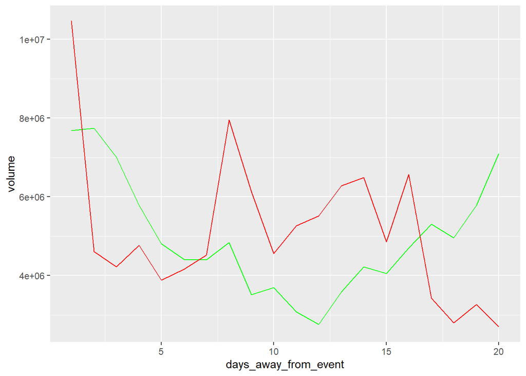

```r
ggplot() +
geom_line(data=etf_pre.out$df.tickers, aes(x=days_away_from_event, y=volume), color='green') +
geom_line(data=etf_post.out$df.tickers, aes(x=days_away_from_event, y=volume), color='red')
```

Wolumen w pierwszym dniu kryzysu ma najwyższą wartość - widać panikę inwestorów. Jednak nie tylko pasywni inwestorzy kupują VTI. Jednak biorąc pod uwagę resztę dni, istnieje nieznaczna rozbieżność wolumenów.

# Stopy zwrotu

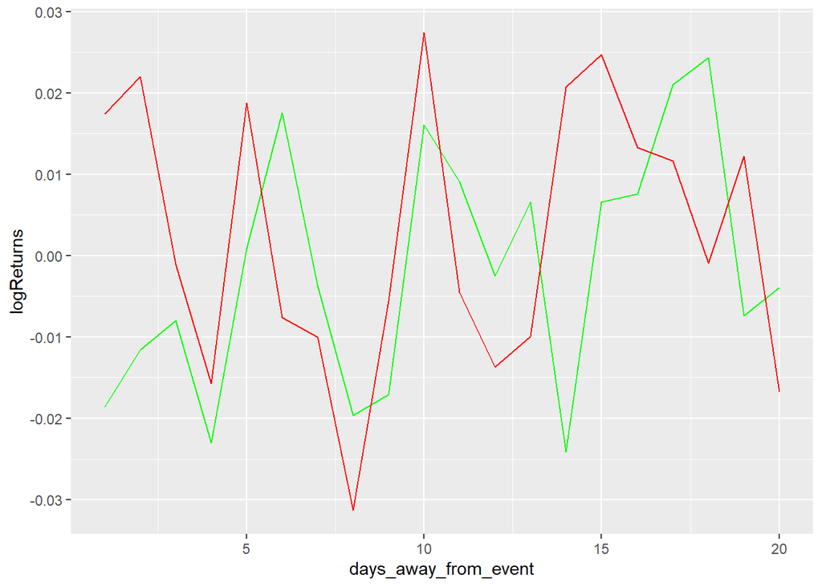

```r
ggplot() +
geom_line(data=etf_pre.out$df.tickers, aes(x=days_away_from_event, y=logReturns, group = 1 ), color='green') +
geom_line(data=etf_post.out$df.tickers, aes(x=days_away_from_event, y=logReturns, group = 1 ), color='red')
```

Stopa zwrotu VTI w dniu kryzysu jest zadziwiająco wysoka - może to być spowodowane jego kompozycją, spółkami z USA (z dala od Rosji i niedotkniętymi bezpośrednio konfliktem)

# Srednie

```r
summary(etf_pre.out$df.tickers[c("volume", "logReturns")])
```

```
##      volume          logReturns
##  Min.   :2757300   Min.   :-0.024100
##  1st Qu.:3960825   1st Qu.:-0.012975
##  Median :4755000   Median :-0.003100
##  Mean   :4971555   Mean   :-0.001485
##  3rd Qu.:5785750   3rd Qu.: 0.007975
##  Max.   :7748900   Max.   : 0.024300
```

```r
summary(etf_post.out$df.tickers[c("volume", "logReturns")])
```

```
##      volume           logReturns
##  Min.   : 2695400   Min.   :-0.031300
##  1st Qu.: 4092500   1st Qu.:-0.009925
##  Median : 4690050   Median :-0.001000
##  Mean   : 5123135   Mean   : 0.002550
##  3rd Qu.: 6170200   3rd Qu.: 0.017750
##  Max.   :10471000   Max.   : 0.027400
```

Wolumen pozostał w dużej mierze bez zmian, ale stopy zwrotu zwiększyły się po kryzysie

# Zmienność woluminów w czasie kryzysu

```r
etf_volume_ratio
```

```
##     volume
## 1 1.362613
```

```r
oil_volume_ratio
```

```
##      volume
## 1 0.6343557
```

Jeszcze raz chciałem podkreślić drastyczne zmiany woluminów dzień przed vs dzień kryzysu.

## Wnioski

I wolumen i stopy zwrotu przed i po kryzysie w dużej mierze zależą od tego, jak dany kryzys wpływa na analizowane aktywo.

W naszym przypadku ropa brent, jako odpowiednik surowca eksportowanego przez Rosję, i z faktu, że Rosja eksportuje także Natural Gas, spowodował niepewność wśród inwestorów, powodując spadek woluminu. Kryzys ten przyczynił się jednak do zwiększenia ceny.

VTI jest ciekawym przypadkiem, bo wzrósł i wolumen i stopy zwrotu, jednak to z uwagi na to jakie potencjalne skutki niesie ten konflikt dla USA (brak bezpośredniego zagrożenia).